# Part I - Prosper Loan Exploration

## by Kayode Fredrick ATOYEBI

## Introduction

> This Loan Data from Prosper (a peer-to-peer lending platform) contains 113,937 loan entries with 81 variables covering a range of loan terms, borrower demographics, and credit profiles.

```python
# import all packages and set plots to be embedded inline
import numpy as np
import pandas as pd
import matplotlib.pyplot as plt
import seaborn as sns
# !pip install -U seaborn
```

```python
prosper =pd.read_csv('prosperLoanData.csv')
prosper.head()
```

|  | ListingKey | ListingNumber | ListingCreationDate | CreditGrade | Term | LoanStatus | ClosedDate | BorrowerAPR | BorrowerRate | LenderYield | ... | LP_ServiceFees | LP_CollectionFees | LP_GrossPrincipalLoss | LP_NetPrincipalLoss | LP_NonPrincipalRecoverypayments | PercentFunded | Recommendations | InvestmentFromFriendsCount | InvestmentFromFriendsAmount | Investors |
| --- | --- | --- | --- | --- | --- | --- | --- | --- | --- | --- | --- | --- | --- | --- | --- | --- | --- | --- | --- | --- | --- |
| 0 | 1021339766868145413AB3B | 193129 | 2007-08-26 19:09:29.263000000 | C | 36 | Completed | 2009-08-14 00:00:00 | 0.16516 | 0.1580 | 0.1380 | ... | -133.18 | 0.0 | 0.0 | 0.0 | 0.0 | 1.0 | 0 | 0 | 0.0 | 258 |
| 1 | 10273602499503308B223C1 | 1209647 | 2014-02-27 08:28:07.900000000 | NaN | 36 | Current | NaN | 0.12016 | 0.0920 | 0.0820 | ... | 0.00 | 0.0 | 0.0 | 0.0 | 0.0 | 1.0 | 0 | 0 | 0.0 | 1 |
| 2 | 0EE9337825851032864889A | 81716 | 2007-01-05 15:00:47.090000000 | HR | 36 | Completed | 2009-12-17 00:00:00 | 0.28269 | 0.2750 | 0.2400 | ... | -24.20 | 0.0 | 0.0 | 0.0 | 0.0 | 1.0 | 0 | 0 | 0.0 | 41 |
| 3 | 0EF5356002482715299901A | 658116 | 2012-10-22 11:02:35.010000000 | NaN | 36 | Current | NaN | 0.12528 | 0.0974 | 0.0874 | ... | -108.01 | 0.0 | 0.0 | 0.0 | 0.0 | 1.0 | 0 | 0 | 0.0 | 158 |
| 4 | 0F023589499656230C5E3E2 | 909464 | 2013-09-14 18:38:39.097000000 | NaN | 36 | Current | NaN | 0.24614 | 0.2085 | 0.1985 | ... | -60.27 | 0.0 | 0.0 | 0.0 | 0.0 | 1.0 | 0 | 0 | 0.0 | 20 |

5 rows × 81 columns

```python
prosper.shape
```

```
(113937, 81)
```

### What is the structure of your dataset?

> The dataset has 113,937 loan records/entries with 81 features/variables

### What is/are the main feature(s) of interest in your dataset?

> I am interested in the LoanStatus, LoanOriginalAmount, and EstimatedReturn features with their correlation or interaction with other variables

### What features in the dataset do you think will help support your investigation into your feature(s) of interest?

| Variable | Description | Why? |
| --- | --- | --- |
| ListingCategory | The category of the listing that the borrower selected when posting their listing: 0 - Not Available, 1 - Debt Consolidation, 2 - Home Improvement, 3 - Business, 4 - Personal Loan, 5 - Student Use, 6 … | To check the most profitable/popular loan category(ies) |
| ListingKey | Unique key for each listing, same value as the 'key' used in the listing object in the API. | Unique Identifier |
| Term | The length of the loan expressed in months. | To check correlation with LoanStatus |
| LoanStatus | The current status of the loan: Cancelled, Chargedoff, Completed, Current, Defaulted, FinalPaymentInProgress, PastDue. The PastDue status will be accompanied by a delinquency bucket. | The main variable in the analysis |
| EstimatedReturn | The estimated return assigned to the listing at the time it was created. Estimated return is the difference between the Estimated Effective Yield and the Estimated Loss Rate. Applicable for loans orig… | To know the (un)profitability of some other variables |
| ProsperRating (Alpha) | The Prosper Rating assigned at the time the listing was created between AA - HR. Applicable for loans originated after July 2009. | To know how different ratings affect LoanStatus |
| BorrowerState | The two letter abbreviation of the state of the address of the borrower at the time the Listing was created. | To check correlation with LoanStatus, EstimatedReturn and ListingCategory |
| Occupation | The Occupation selected by the Borrower at the time they created the listing. | To check correlation with LoanStatus, EstimatedReturn and ListingCategory |
| EmploymentStatus | The employment status of the borrower at the time they posted the listing. | To check correlation with LoanStatus |
| EmploymentStatusDuration | The length in months of the employment status at the time the listing was created. | To check correlation with LoanStatus |
| IsBorrowerHomeowner | A Borrower will be classified as a homowner if they have a mortgage on their credit profile or provide documentation confirming they are a homeowner. | To check correlation with LoanStatus |
| OpenCreditLines | Number of open credit lines at the time the credit profile was pulled. | To check correlation with LoanStatus |
| OpenRevolvingAccounts | Number of open revolving accounts at the time the credit profile was pulled. | To check correlation with LoanStatus |
| InquiriesLast6Months | Number of inquiries in the past six months at the time the credit profile was pulled. | To know whether the individual has applied to other Fin. firms and its correlation with LoanStatus |
| CurrentDelinquencies | Number of accounts delinquent at the time the credit profile was pulled. | To check correlation with LoanStatus |
| IncomeRange | The income range of the borrower at the time the listing was created. | To check correlation with LoanStatus and EstimatedReturn |
| IncomeVerifiable | The borrower indicated they have the required documentation to support their income. | To ensure that only records with verified IncomeRange are included in the analysis |
| LoanOriginalAmount | The origination amount of the loan. | To know if some other variables influence how much is approved |
| LoanOriginationDate | The date the loan was originated. | Time Series Analysis |
| ListingCreationDate | The date the listing was created. | To filter off records before July 2009 |
| DebtToIncomeRatio | The debt to income ratio of the borrower at the time the credit profile was pulled. This value is Null if the debt to income ratio is not available. This value is capped at 10.01 (any debt to income r… | To check correlation with LoanStatus and Prosper Rating |

## Preliminary Wrangling

```python
#select the features of interest
select_features =['ListingKey', 'LoanOriginationDate', 'LoanStatus',
                  'Term', "ListingCreationDate", 'IncomeRange', 'IncomeVerifiable',
                  'EstimatedReturn', 'ListingCategory (numeric)',  'ProsperRating (Alpha)',
                  'BorrowerState', 'Occupation', 'EmploymentStatus', 'EmploymentStatusDuration',
                  'IsBorrowerHomeowner', 'OpenCreditLines', 'OpenRevolvingAccounts', 'InquiriesLast6Months',
                  'CurrentDelinquencies',  'LoanOriginalAmount', 'DebtToIncomeRatio']
prosper_new=prosper[select_features]

#filter out entries earlier than July 2009 when most of the features takes effect to avoid null values on important variables
prosper_new=prosper_new.loc[pd.to_datetime(prosper_new.ListingCreationDate) >= '2009-07']

#rename columns
prosper_new.rename(columns={'ProsperRating (Alpha)': 'ProsperRating', "ListingCategory (numeric)": "ListingCategory"}, inplace=True)


#filter off entries where the income is not verifiable
prosper_new= prosper_new[prosper_new.IncomeVerifiable ==True]

#drop superfluous columns
prosper_new.drop(["ListingCreationDate",'IncomeVerifiable'], axis=1, inplace=True)

prosper_new.head()
```

|  | ListingKey | LoanOriginationDate | LoanStatus | Term | IncomeRange | EstimatedReturn | ListingCategory | ProsperRating | BorrowerState | Occupation | EmploymentStatus | EmploymentStatusDuration | IsBorrowerHomeowner | OpenCreditLines | OpenRevolvingAccounts | InquiriesLast6Months | CurrentDelinquencies | LoanOriginalAmount | DebtToIncomeRatio |
| --- | --- | --- | --- | --- | --- | --- | --- | --- | --- | --- | --- | --- | --- | --- | --- | --- | --- | --- | --- |
| 1 | 10273602499503308B223C1 | 2014-03-03 00:00:00 | Current | 36 | $50,000-74,999 | 0.05470 | 2 | A | CO | Professional | Employed | 44.0 | False | 14.0 | 13 | 3.0 | 0.0 | 10000 | 0.18 |
| 3 | 0EF5356002482715299901A | 2012-11-01 00:00:00 | Current | 36 | $25,000-49,999 | 0.06000 | 16 | A | GA | Skilled Labor | Employed | 113.0 | True | 5.0 | 7 | 0.0 | 4.0 | 10000 | 0.15 |
| 4 | 0F023589499656230C5E3E2 | 2013-09-20 00:00:00 | Current | 36 | $100,000+ | 0.09066 | 2 | D | MN | Executive | Employed | 44.0 | True | 19.0 | 6 | 1.0 | 0.0 | 15000 | 0.26 |
| 5 | 0F05359734824199381F61D | 2013-12-24 00:00:00 | Current | 60 | $100,000+ | 0.07077 | 1 | B | NM | Professional | Employed | 82.0 | True | 17.0 | 13 | 0.0 | 0.0 | 15000 | 0.36 |
| 6 | 0F0A3576754255009D63151 | 2013-04-18 00:00:00 | Current | 36 | $25,000-49,999 | 0.11070 | 1 | E | KS | Sales - Retail | Employed | 172.0 | False | 7.0 | 6 | 0.0 | 0.0 | 3000 | 0.27 |

```python
#Check dtype
prosper_new.dtypes
```

```
ListingKey                   object
LoanOriginationDate          object
LoanStatus                   object
Term                          int64
IncomeRange                  object
EstimatedReturn             float64
ListingCategory               int64
ProsperRating                object
BorrowerState                object
Occupation                   object
EmploymentStatus             object
EmploymentStatusDuration    float64
IsBorrowerHomeowner            bool
OpenCreditLines             float64
OpenRevolvingAccounts         int64
InquiriesLast6Months        float64
CurrentDelinquencies        float64
LoanOriginalAmount            int64
DebtToIncomeRatio           float64
dtype: object
```

```python
#Check for null values
prosper_new.isnull().sum()
```

```
ListingKey                     0
LoanOriginationDate            0
LoanStatus                     0
Term                           0
IncomeRange                    0
EstimatedReturn                0
ListingCategory                0
ProsperRating                  0
BorrowerState                  0
Occupation                  1333
EmploymentStatus               0
EmploymentStatusDuration      14
IsBorrowerHomeowner            0
OpenCreditLines                0
OpenRevolvingAccounts          0
InquiriesLast6Months           0
CurrentDelinquencies           0
LoanOriginalAmount             0
DebtToIncomeRatio             11
dtype: int64
```

#### Drop the entries containing null values for EmploymentStatusDuration and DebtToIncomeRatio since they are small. The null values in the Occupation variable would be further examined

```python
prosper_new =prosper_new.loc[~((prosper_new.EmploymentStatusDuration.isnull()) |(prosper_new.DebtToIncomeRatio.isnull()))]
```

```python
#Examine the 1327 NaN values in the Occupation column
(prosper_new
     .loc[prosper_new.Occupation.isnull()]
     .loc[:,['Occupation', 'EmploymentStatus','EmploymentStatusDuration','IncomeRange']]
     .sort_values(by='EmploymentStatus')
     .head(10)
)
```

|  | Occupation | EmploymentStatus | EmploymentStatusDuration | IncomeRange |
| --- | --- | --- | --- | --- |
| 91583 | NaN | Full-time | 13.0 | $50,000-74,999 |
| 34 | NaN | Other | 426.0 | $25,000-49,999 |
| 78973 | NaN | Other | 70.0 | $50,000-74,999 |
| 78809 | NaN | Other | 123.0 | $50,000-74,999 |
| 78779 | NaN | Other | 0.0 | $25,000-49,999 |
| 78756 | NaN | Other | 0.0 | $25,000-49,999 |
| 78711 | NaN | Other | 442.0 | $75,000-99,999 |
| 78574 | NaN | Other | 13.0 | $25,000-49,999 |
| 78478 | NaN | Other | 0.0 | $50,000-74,999 |
| 78282 | NaN | Other | 0.0 | $1-24,999 |

#### It seems only one person is employed out of the people with null values in the occupation column.

```python
#Drop the entries with null values in the Occupation column
prosper_new=prosper_new.loc[~(prosper_new.Occupation.isnull())]
```

```python
#Check out the Employement Status and clean if neccessary
prosper_new.EmploymentStatus.value_counts()
```

```
Employed        65883
Full-time        7571
Other            2194
Retired           320
Part-time         199
Not employed        1
Name: EmploymentStatus, dtype: int64
```

> 1. Group full-time, part-time, and self-employed as employed to reduce the categories.
> 2. Group Retired as 'Not employed'
> 3. If the corresponding Occupation value is not 'Other' or 'Others, change the EmploymentStatus to 'Employed' as this means the person has a job

```python
prosper_new.EmploymentStatus=prosper_new.EmploymentStatus.replace({'Full-time': 'Employed', 'Part-time':
                                                                   'Employed', 'Self-employed': 'Employed',
                                                                  'Retired': 'Not employed'})

prosper_new.loc[(~prosper_new.Occupation.isin(['Other','Others'])), 'EmploymentStatus'] = 'Employed'
#Test
prosper_new.EmploymentStatus.value_counts(dropna=False)
```

```
Employed        73665
Other            2189
Not employed      314
Name: EmploymentStatus, dtype: int64
```

```python
#Check out the new structure
prosper_new.shape
```

```
(76168, 19)
```

```python
#Check out the credit rating (ProsperRating) variable
prosper_new.ProsperRating.value_counts(dropna=False)
```

```
C     16485
B     14370
A     13486
D     12623
E      8435
HR     5674
AA     5095
Name: ProsperRating, dtype: int64
```

```python
#Convert ProsperRating to a category
rating_cat =['HR','E','D','C','B','A','AA']
credit_cat =pd.api.types.CategoricalDtype(categories=rating_cat, ordered=True)
prosper_new.ProsperRating=prosper_new.ProsperRating.astype(credit_cat)
prosper_new.ProsperRating.dtypes
```

```
CategoricalDtype(categories=['HR', 'E', 'D', 'C', 'B', 'A', 'AA'], ordered=True)
```

```python
#Examine LoanStatus variable
prosper_new.LoanStatus.value_counts(dropna=False)
```

```
Current                   51123
Completed                 17686
Chargedoff                 4444
Defaulted                   885
Past Due (1-15 days)        714
Past Due (31-60 days)       322
Past Due (91-120 days)      277
Past Due (61-90 days)       275
Past Due (16-30 days)       241
FinalPaymentInProgress      187
Past Due (>120 days)         14
Name: LoanStatus, dtype: int64
```

#### Reorder the variable as follows:

1. Change 'Defaulted', 'Chargedoff' and all 'Past Due' buckets to 'Not Completed' as they have a higher chance of not completing
2. Merge 'FinalPaymentInProgress with 'Completed' as they are about to make the final payment to complete the loan
3. Leave'Current' Status as it is as they have equal chance of defaulting or completing all loan payment

```python
prosper_new.LoanStatus.replace({'Past Due (>120 days)': 'Not Completed',
                                'Past Due (1-15 days)': 'Not Completed',
                                'Past Due (16-30 days)': 'Not Completed',
                                'Past Due (31-60 days)': 'Not Completed',
                                'Past Due (61-90 days)': 'Not Completed',
                                'Past Due (91-120 days)': 'Not Completed',
                                'Chargedoff': 'Not Completed',
                                'Defaulted': 'Not Completed',
                                'FinalPaymentInProgress': 'Completed'
                               }, inplace=True)
#Test
prosper_new.LoanStatus.value_counts()
```

```
Current          51123
Completed        17873
Not Completed     7172
Name: LoanStatus, dtype: int64
```

## Univariate Exploration

#### Question: What's the proportion of homeowners to Non-homeowners in the data:

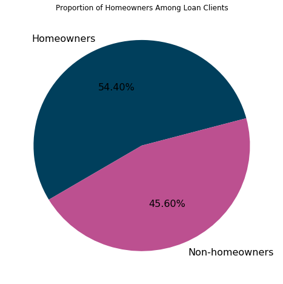

```python
#Visualization
plt.figure(figsize=(8,8))
plt.title('Proportion of Homeowners Among Loan Clients')
homeowner=prosper_new.IsBorrowerHomeowner.map({True: 'Homeowners', False: 'Non-homeowners'}).value_counts()
plt.pie(homeowner, labels=homeowner.index, startangle=15,colors=['#003f5c', '#bc5090'],autopct='%1.2f%%', textprops={'fontsize': 16});
```

##### Observations: It seems homeowners are slighly more than non-homeowners. Whether that has impact on the loan status would need to be explored further

#### Question: Which income range applies for loan the most

```python
prosper_new.IncomeRange.value_counts(dropna=False)
```

```
$50,000-74,999    23677
$25,000-49,999    21402
$100,000+         13970
$75,000-99,999    13542
$1-24,999          3576
Not employed          1
Name: IncomeRange, dtype: int64
```

```python
# Examine the 'Not Employed' entry
prosper_new.loc[(prosper_new.IncomeRange =='$0') | (prosper_new.IncomeRange =='Not employed')]
```

|  | ListingKey | LoanOriginationDate | LoanStatus | Term | IncomeRange | EstimatedReturn | ListingCategory | ProsperRating | BorrowerState | Occupation | EmploymentStatus | EmploymentStatusDuration | IsBorrowerHomeowner | OpenCreditLines | OpenRevolvingAccounts | InquiriesLast6Months | CurrentDelinquencies | LoanOriginalAmount | DebtToIncomeRatio |
| --- | --- | --- | --- | --- | --- | --- | --- | --- | --- | --- | --- | --- | --- | --- | --- | --- | --- | --- | --- |
| 21386 | BC0C3466047510716AB85FC | 2009-11-04 00:00:00 | Completed | 36 | Not employed | 0.1331 | 6 | D | MN | Student - Community College | Employed | 38.0 | True | 11.0 | 8 | 0.0 | 4.0 | 1000 | 0.34 |

```python
#drop entry
prosper_new =prosper_new.drop(prosper_new[(prosper_new.IncomeRange=='$0')| (prosper_new.IncomeRange =='Not employed')].index, axis=0)


#Convert to Category
income_cat = ['$1-24,999', '$25,000-49,999', '$50,000-74,999','$75,000-99,999','$100,000+']
income= pd.api.types.CategoricalDtype(categories=income_cat, ordered=True)
prosper_new.IncomeRange =prosper_new.IncomeRange.astype(income)
#Test
prosper_new.IncomeRange.value_counts()
```

```
$50,000-74,999    23677
$25,000-49,999    21402
$100,000+         13970
$75,000-99,999    13542
$1-24,999          3576
Name: IncomeRange, dtype: int64
```

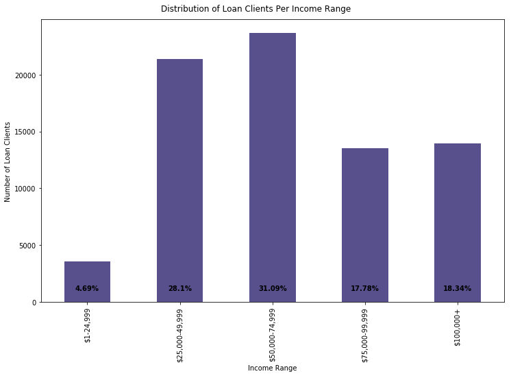

```python
#Group by income range
income_plot =prosper_new.groupby('IncomeRange')['ListingKey'].size()

#Create a function for plotting
def plotter(frame, color_code):
    #Get the total entries
    total=frame.size

    #plot
    if frame.index.size < 7:
        ax =frame.plot(kind='bar',figsize= (11,8),color =color_code)
        for i, v in enumerate(frame.transform(lambda x: (x/x.sum())*100)):
            ax.text(i, (v*total*0.01)+1000, f'{str(round(v,2))}%', ha='center', fontweight='bold')
    else:
        ax =frame.plot(kind='barh',figsize= (11,8),color =color_code)
        for i, v in enumerate(frame.transform(lambda x: (x/x.sum())*100)):
            ax.text((v*total*0.01)+1000, i, f'{str(round(v,2))}%', ha='center', fontweight='bold')

    return ax

plotter(income_plot, '#58508d')
plt.xlabel('Income Range')
plt.ylabel('Number of Loan Clients')
plt.suptitle('Distribution of Loan Clients Per Income Range')
plt.tight_layout(pad=3);
```

#### Observation: Seems people in the $50,000-74,999 income bracket takes out the most loans

#### Question: Which state(s) do most loan clients come from?

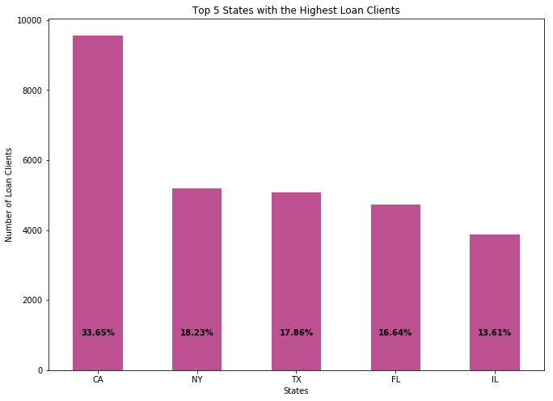

```python
#Select the top 5 states for visualization

#group by states
states = prosper_new.groupby('BorrowerState')['ListingKey'].count().sort_values(ascending=False)[:5]

#plot
plotter(states, '#bc5090')

plt.title('Top 5 States with the Highest Loan Clients')
plt.xticks(rotation=0)
plt.xlabel('States')
plt.ylabel('Number of Loan Clients');
```

#### Question: Which month(s) do people take out the most loans?

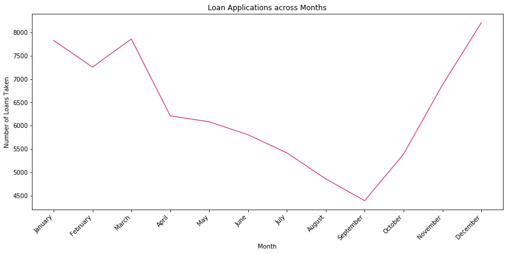

```python
months=['January', 'February', 'March', 'April','May', 'June',
        'July', 'August', 'September', 'October', 'November', 'December']

month_loan =(prosper_new
     .assign(LoanMonth= pd.to_datetime(prosper_new.LoanOriginationDate).dt.month_name())
     .pipe(lambda df: df.groupby('LoanMonth')['ListingKey'].count().reindex(months[::-1]))
     )


ax = month_loan.plot(kind='line', color ='#d45087', figsize=(14,6))
ax.set_xticks(range(len(months)))
ax.set_xticklabels(months, rotation=45, ha='right')
ax.set_title('Loan Applications across Months')
plt.suptitle='Total Loans Taken Each Month'
plt.ylabel('Number of Loans Taken')
plt.xlabel('Month');
```

#### Question: What's the top 5 occupations of those listed

```python
#Check out Occupation column
prosper_new.Occupation.value_counts(dropna=False)
```

```
Other                                 18486
Professional                           9911
Executive                              3203
Computer Programmer                    3037
Teacher                                2777
Analyst                                2682
Administrative Assistant               2603
Accountant/CPA                         2411
Nurse (RN)                             2120
Clerical                               2059
Skilled Labor                          2032
Sales - Commission                     1978
Retail Management                      1900
Sales - Retail                         1722
Police Officer/Correction Officer      1273
Truck Driver                           1216
Laborer                                1162
Civil Service                          1131
Engineer - Mechanical                  1098
Construction                           1050
Food Service Management                 935
Engineer - Electrical                   872
Medical Technician                      863
Military Enlisted                       797
Tradesman - Mechanic                    742
Food Service                            719
Attorney                                710
Social Worker                           551
Postal Service                          480
Professor                               436
                                      ...
Military Officer                        247
Principal                               247
Bus Driver                              240
Pharmacist                              218
Teacher's Aide                          187
Engineer - Chemical                     174
Pilot - Private/Commercial              149
Clergy                                  143
Architect                               136
Car Dealer                              122
Chemist                                 108
Biologist                                94
Psychologist                             90
Flight Attendant                         87
Landscaping                              80
Realtor                                  79
Student - College Graduate Student       73
Religious                                71
Tradesman - Plumber                      66
Investor                                 64
Tradesman - Carpenter                    47
Dentist                                  45
Student - College Senior                 37
Judge                                    22
Homemaker                                22
Student - College Junior                 19
Student - College Freshman               12
Student - College Sophomore               9
Student - Community College               4
Student - Technical School                1
Name: Occupation, Length: 67, dtype: int64
```

```python
#Combine some subcategories:  MS Excel was used to visually inspect the columns
prosper_new.Occupation= (prosper_new.Occupation
                             .str.strip()
                             .str.replace(r'(Sales)\s+-\s+\w+', 'Salesperson')
                             .str.replace(r'(Engineer)\s+-\s+\w+', 'Engineer')
                             .str.replace(r'(Teacher)(\'s)?(\s+)?(\w+)?', 'Teacher') #including Teacher's Aide
                             .str.replace(r'(Pilot)\s+-\s+\w+/\w+', 'Pilot')
                             .str.replace(r'(Tradesman)\s+-\s+\w+', 'Tradesman')
                             #Create a 'Health Worker' occupation
                             .str.replace(r'(Nurse)(\'s)?(\s+)?\(?\w+\)?', 'Health Worker') #including Nurse's Aide
                             .str.replace('Medical Technician', 'Health Worker')
                             .str.replace('Pharmacist', 'Health Worker')
                             .str.replace('Doctor', 'Health Worker')
                             .str.replace('Dentist', 'Health Worker')
                             .str.replace(r'(Student)\s+-\s+\w+(\s+\w+)?(\s+\w+)?', 'Student')

                             .str.replace('Others','Other')
                        )
#Check out the top 10 occupations
prosper_new.Occupation.value_counts(dropna=False)[:10]
```

```
Other                       18486
Professional                 9911
Health Worker                4333
Salesperson                  3700
Executive                    3203
Computer Programmer          3037
Teacher                      2964
Analyst                      2682
Administrative Assistant     2603
Accountant/CPA               2411
Name: Occupation, dtype: int64
```

#### 'Other' doesn't convey any information. Same with 'Professional' and 'Executive' so those entries would be dropped for this analysis and some other analysis

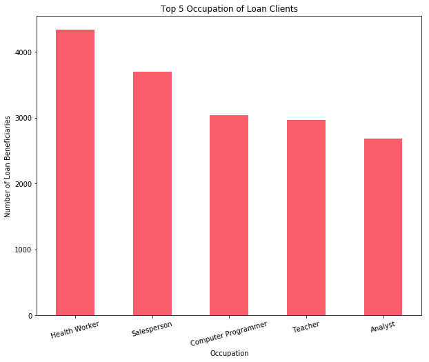

```python
(prosper_new
     #filter off "Other", "Professional", and "Executive"
     .loc[~(prosper_new.Occupation .isin(['Other', 'Professional', 'Executive']))]
     #group by Occupation and select the first
     .pipe(lambda df: df.groupby('Occupation')['ListingKey'].count().sort_values(ascending=False))[:5]
     .plot(kind='bar',title='Top 5 Occupation of Loan Clients', figsize=(10,8),color ='#f95d6a')
)
plt.xlabel('Occupation')
plt.ylabel('Number of Loan Beneficiaries')
plt.xticks(rotation=15);
```

#### Observations: The top occupations of loan customers are health workers, salespeople and computer programmers. Whether they complete their payment or not should be further investigated.

### Discuss the distribution(s) of your variable(s) of interest. Were there any unusual points? Did you need to perform any transformations?

> There was need to reduce the categories in the LoanStatus column for easier analysis. Also the credit rating(Prosper Rating) was changed to a ordered categorical dtype

## Bivariate Exploration

#### Question: Which 5 state(s) could bring in the most returns if there's no default?

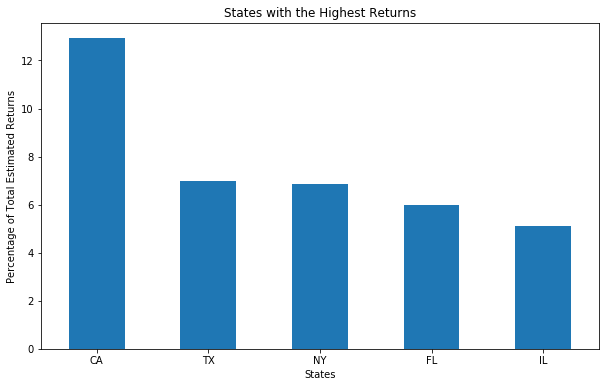

```python
#Create a new 'LoanReturn' feature by multiplying the estimated return percentage with the original loan amount
prosper_new['LoanReturn']= prosper_new.LoanOriginalAmount.mul(prosper_new.EstimatedReturn)
topstates=(prosper_new
     #group the dataframe
     .pipe(lambda df: df.groupby('BorrowerState')['LoanReturn'].sum().transform(lambda x: (x/x.sum())*100))
     .sort_values(ascending=False)[:5]
     .plot(kind='bar', figsize=(10,6), rot=0, title='States with the Highest Returns', color ='#1f77b4')
)
plt.xlabel('States')
plt.ylabel('Percentage of Total Estimated Returns');
```

#### Observations: California (should) fetch the highest percentage of returns made on loans. It could be because it has the highest number of loan clients

#### Question: Does being a homeowner have an effect of loan payment?

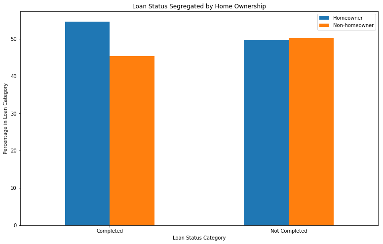

```python
(prosper_new
     #filter off current loans
     .loc[~(prosper_new.LoanStatus =='Current')]
     .assign(IsBorrowerHomeowner= prosper_new.IsBorrowerHomeowner.map({True:'Homeowner', False: 'Non-homeowner'}))
     .groupby(['LoanStatus', 'IsBorrowerHomeowner']).ListingKey.count().groupby(level=0).transform(lambda x: (x/x.sum())*100)
     .unstack()
     .plot(kind='bar', figsize=(13,8), rot=0, title='Loan Status Segregated by Home Ownership')
)
plt.ylabel('Percentage in Loan Category')
plt.xlabel('Loan Status Category')
plt.legend(loc='best');
```

#### Observation: Apparently, (not) being a homeowner doesn't have much effect on whether a customer defaults, completes or miss a payment

#### Question: Does Credit affect the amount the requested for and approved?

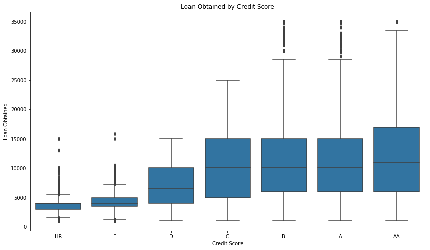

```python
plt.figure(figsize=(14,8))
ax=sns.boxplot(data=prosper_new, x='ProsperRating', y='LoanOriginalAmount', color=sns.color_palette()[0])
ax.set_title('Loan Obtained by Credit Score')
plt.xlabel('Credit Score')
plt.ylabel('Loan Obtained');
```

#### Observations: The better your credit score, the higher the amount of loan you can apply for

#### Question: What seem to determine how much is loaned approved?

```python
#create a correlation matric of the dataset
prosper_matrix =prosper_new.corr()

#find how much other variables correlate wit the original loan approved
prosper_matrix['LoanOriginalAmount'].sort_values(ascending=False)
```

```
LoanOriginalAmount          1.000000
LoanReturn                  0.877947
Term                        0.339464
OpenCreditLines             0.205173
OpenRevolvingAccounts       0.204173
IsBorrowerHomeowner         0.171123
EmploymentStatusDuration    0.067955
DebtToIncomeRatio          -0.017715
InquiriesLast6Months       -0.097320
CurrentDelinquencies       -0.118249
ListingCategory            -0.205962
EstimatedReturn            -0.288192
Name: LoanOriginalAmount, dtype: float64
```

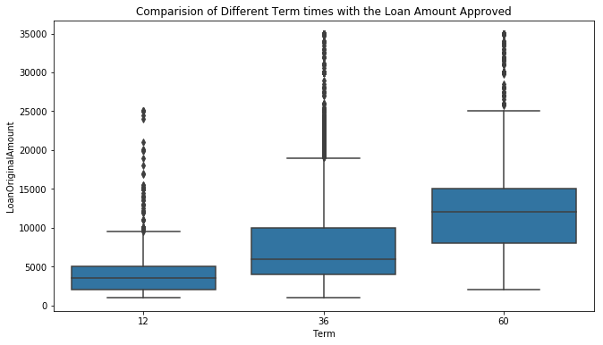

```python
##Term Variable
plt.figure(figsize=(10,6))
color= sns.color_palette()[0]

ax =sns.boxplot(x= 'Term', y='LoanOriginalAmount', color= color, data=prosper_new)
ax.set_title("Comparision of Different Term times with the Loan Amount Approved")
plt.tight_layout(pad=3);
```

#### Observation: The boxplot indeed confirms that the higher the loan repayment term, the higher the amount approved. The 75th percentile of a lower term time (the upper bound of the box) is lower than the median or 50th percentile of the next term time (the middle line in the box)

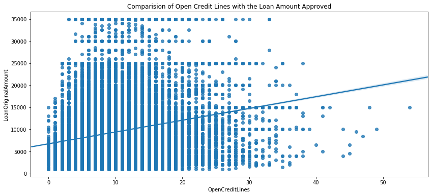

```python
#Open Credit Lines
plt.figure(figsize=(14,6))
ax =sns.regplot(data = prosper_new, x = 'OpenCreditLines', y = 'LoanOriginalAmount')
ax.set_title('Comparision of Open Credit Lines with the Loan Amount Approved');
```

#### Observations: Customers with 7-3 open credit lines tend to get higher loans

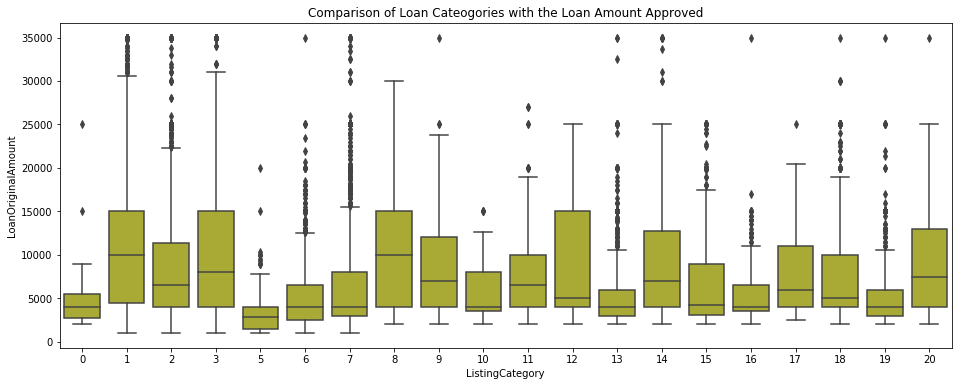

```python
#Listing Category
plt.figure(figsize=(14,6))
color_base = sns.color_palette()[8]
ax=sns.boxplot(data = prosper_new, x = 'ListingCategory',color = color_base, y = 'LoanOriginalAmount')
ax.set_title('Comparison of Loan Cateogories with the Loan Amount Approved')
plt.tight_layout(pad=3);
```

#### Observation: Category 5 (Student Use) gets the lowest loan amounts.On the other hand, Categories 1(Debt Consolidation), 3 (Business), and 8(Baby &Adoption) gets the highest loan amounts

#### Question: Do people who apply for these three categories above pay for their loans completely or they default?

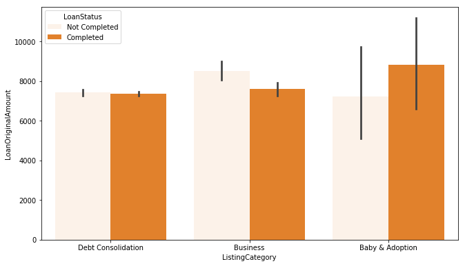

```python
prosper_category =(prosper_new
                    .loc[(prosper_new.ListingCategory .isin([1,3,8])) & (prosper_new.LoanStatus !='Current')]
                    .assign(ListingCategory =lambda df:df.ListingCategory.map({1 : 'Debt Consolidation', 3 : 'Business', 8 : 'Baby & Adoption'}))
                  )
plt.figure(figsize=(10,6))
color_base = sns.color_palette()[1]
sns.barplot(data = prosper_category, x = 'ListingCategory', hue='LoanStatus',color = color_base, y = 'LoanOriginalAmount')
plt.subtitle='Loan Completion Comparison among the Top Three Popular Categories'
plt.tight_layout(pad=3);
```

#### Question: Does previous record of deliquency have importance regarding loan status?

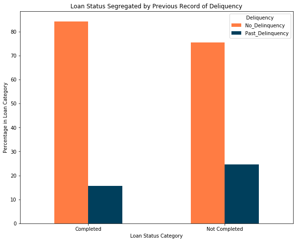

```python
#create a new feature that indicates whether a client the category of deliquency
prosper_new.loc[prosper_new.CurrentDelinquencies== 0.0, 'Deliquency'] = 'No_Delinquency'
prosper_new.loc[(prosper_new.CurrentDelinquencies >0.0), 'Deliquency'] = 'Past_Delinquency'
(prosper_new
     #filter off current loans
     .loc[~(prosper_new.LoanStatus =='Current')]
     .groupby(['LoanStatus', 'Deliquency']).ListingKey.count().groupby(level=0).transform(lambda x: (x/x.sum())*100)
     .unstack()
     .plot(kind='bar', rot=0,figsize=(10,8), color=['#ff7c43', '#003f5c'],title='Loan Status Segregated by Previous Record of Deliquency')
)
plt.ylabel('Percentage in Loan Category')
plt.xlabel('Loan Status Category');
```

#### Question: What about Credit Rating? Does it have any effect on Loan Status?

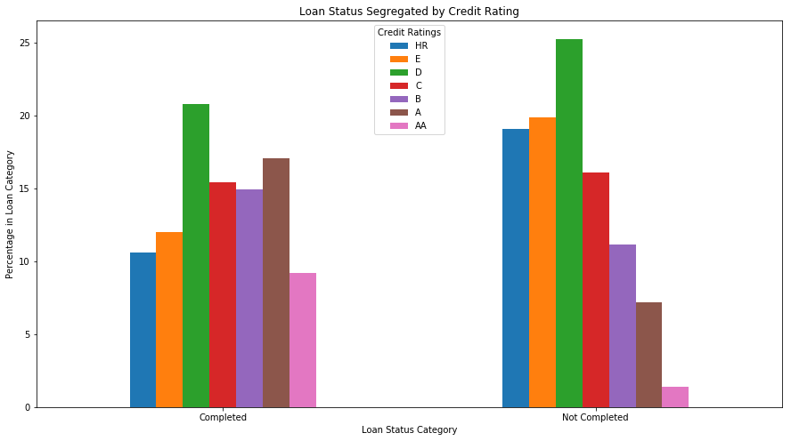

```python
(prosper_new
     #filter off current loans
     .loc[~(prosper_new.LoanStatus =='Current')]
     .groupby(['LoanStatus', 'ProsperRating']).ListingKey.count().groupby(level=0).transform(lambda x: (x/x.sum())*100)
     .unstack()
     .plot(kind='bar', figsize=(15,8), rot=0,title='Loan Status Segregated by Credit Rating')
)
plt.ylabel('Percentage in Loan Category')
plt.xlabel('Loan Status Category')
plt.legend(loc='upper center', title='Credit Ratings');
```

#### Observations: People with A or AA Credit rating seems the ideal loan customers

#### Question: Which Categories brought in or likely to bring the most money?

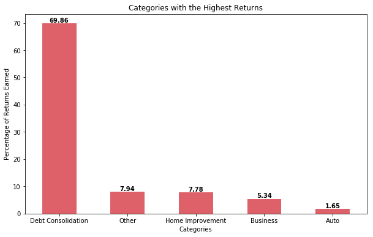

```python
top_cat=(prosper_new
     .assign(ListingCategory =lambda df:df.ListingCategory.map({0 : 'Not Available', 1 : 'Debt Consolidation', 2 : 'Home Improvement', 3 : 'Business', 4 : 'Personal Loan', 5 : 'Student Use', 6 : 'Auto', 7: 'Other', 8 : 'Baby&Adoption', 9 : 'Boat', 10 : 'Cosmetic Procedure', 11 : 'Engagement Ring', 12 : 'Green Loans', 13 : 'Household Expenses', 14 : 'Large Purchases', 15 : 'Medical/Dental', 16 : 'Motorcycle', 17 : 'RV', 18 : 'Taxes', 19 : 'Vacation', 20 : 'Wedding Loans'}))
     #group the dataframe
     .pipe(lambda df: df.groupby('ListingCategory')['LoanReturn'].sum().transform(lambda x: (x/x.sum())*100))
     .sort_values(ascending=False)[:5]
    )
top_cat.plot(kind='bar', figsize=(10,6), rot=0, title='Categories with the Highest Returns', color ='#de6069')
for i, v in enumerate(top_cat.values):
    plt.text(i,v+0.5, str(round(v,2)), ha='center', fontweight='bold')
plt.xlabel('Categories')
plt.ylabel('Percentage of Returns Earned');
```

#### Observation: Debt Consolidation is the market to double down on

#### Question: Is debt consolidation also the most popular category?

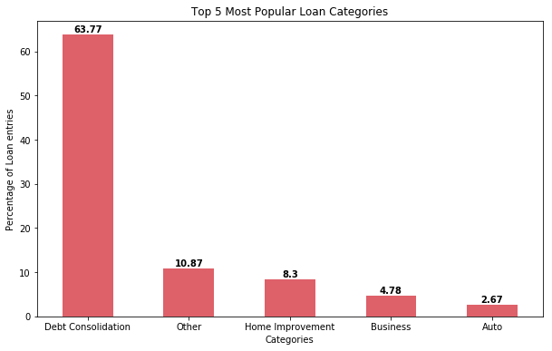

```python
cat_ident=(prosper_new
     .assign(ListingCategory =lambda df:df.ListingCategory.map({0 : 'Not Available', 1 : 'Debt Consolidation', 2 : 'Home Improvement', 3 : 'Business', 4 : 'Personal Loan', 5 : 'Student Use', 6 : 'Auto', 7: 'Other', 8 : 'Baby&Adoption', 9 : 'Boat', 10 : 'Cosmetic Procedure', 11 : 'Engagement Ring', 12 : 'Green Loans', 13 : 'Household Expenses', 14 : 'Large Purchases', 15 : 'Medical/Dental', 16 : 'Motorcycle', 17 : 'RV', 18 : 'Taxes', 19 : 'Vacation', 20 : 'Wedding Loans'}))
     #group the dataframe
     .pipe(lambda df: df.groupby('ListingCategory')['ListingKey'].count().transform(lambda x: (x/x.sum())*100))
     .sort_values(ascending=False)[:5]
    )
cat_ident.plot(kind='bar', figsize=(10,6), rot=0, title='Top 5 Most Popular Loan Categories', color ='#de6069')
for i, v in enumerate(cat_ident.values):
    plt.text(i,v+0.5, str(round(v,2)), ha='center', fontweight='bold')
plt.xlabel('Categories')
plt.ylabel('Percentage of Loan entries');
```

#### Observation: Yep, it is

#### Question: So is there a special consideration or a correlation between credit rating and debt consolidation?

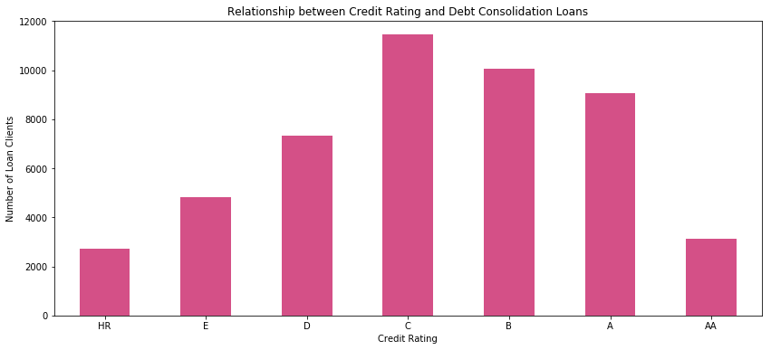

```python
top_debt =(prosper_new
             .loc[prosper_new.ListingCategory == 1] #which is the dummy for Debt Consolidation
             #group by Occupation and select the first
             .pipe(lambda df: df.groupby('ProsperRating')['ListingKey'].count())
          )

# plotter(top_debt, '#d45087' )
top_debt.plot(kind='bar', color ='#d45087', title='Relationship between Credit Rating and Debt Consolidation Loans', rot=0,figsize=(14,6))
plt.xlabel('Credit Rating')
plt.ylabel('Number of Loan Clients');
```

#### Observations: It seems people with C Credit Ratings apply for Debt Consolidation Loans the most or probably they were the categoy whose loans were readily approved.

### Talk about some of the relationships you observed in this part of the investigation. How did the feature(s) of interest vary with other features in the dataset?

> Either the loan firm or cliens have preference for debt consolidation loans.

### Did you observe any interesting relationships between the other features (not the main feature(s) of interest)?

> A combination of factors affect how much was approved and how much the estimated return from a loan

## Multivariate Exploration

> Create plots of three or more variables to investigate your data even further. Make sure that your investigations are justified, and follow from your work in the previous sections.

#### Question: Is there any correlation between the numerical variables

```python
prosper_numeric=prosper_new.loc[:,(prosper_new.columns== 'LoanOriginalAmount') | (prosper_new.dtypes=='float64')]
```

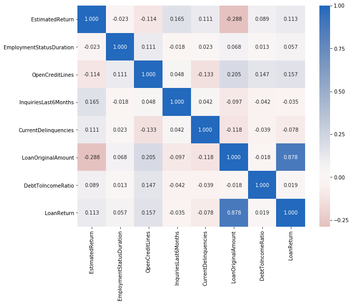

```python
plt.figure(figsize = [10, 8])
sns.heatmap(prosper_numeric.corr(), annot = True, fmt = '.3f',
           cmap = 'vlag_r', center = 0)
plt.title='Correlation of some Numeric Variables in the Loan Dataset';
```

#### Question: Still on Debt Consolidation, which top occupations apply for debt consolidation and what percentage eventually complete payment?

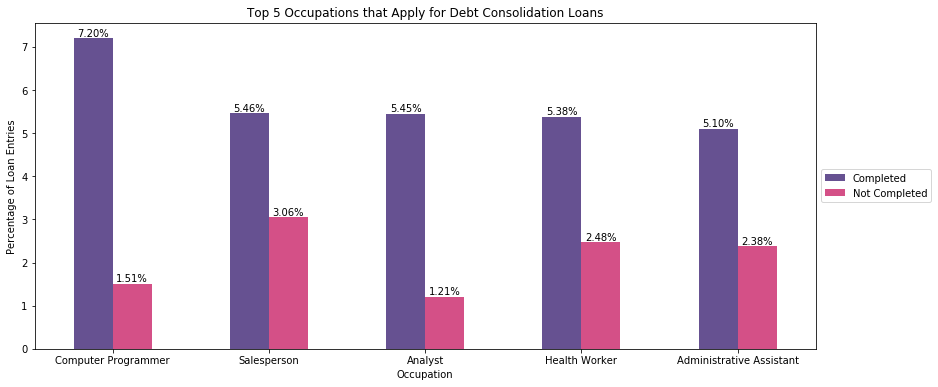

```python
top_debt_payment =(prosper_new
                     .loc[prosper_new.ListingCategory == 1] #which is the dummy for Debt Consolidation
                     #filter off "Other", "Professional", and "Executive"
                     .loc[~(prosper_new.Occupation .isin(['Other', 'Professional', 'Executive']))]
                     #filter of current loans
                    .loc[~(prosper_new.LoanStatus =='Current')]
                     #group by Occupation and select the first
                     .pipe(lambda df: df.groupby(['Occupation', 'LoanStatus'])['ListingKey'].count().transform(lambda x: x/x.sum()*100).unstack().sort_values(by='Completed',ascending=False))[:5]
          )
top_debt_payment
ax = top_debt_payment.plot(kind='bar',color =['#665191','#d45087'],title='Top 5 Occupations that Apply for Debt Consolidation Loans',rot=0,figsize=(14,6))
plt.xlabel('Occupation')
plt.ylabel('Percentage of Loan Entries')

# Move the legend outside of the chart to make the chart more smoother
ax.legend(loc='center left', bbox_to_anchor=(1, 0.5))

# Add values on top of the bars
for p in ax.patches:
    ax.annotate('{:.2f}%'.format(p.get_height()),
                (p.get_x() + p.get_width() / 2., p.get_height()),
                ha='center', va='center', xytext=(0, 5),
                textcoords='offset points')
```

#### Observations: Computer programmers and salespeople seems to love this type of loans.

#### Question: Which occupation fetches the most returns. Is it the same group above?

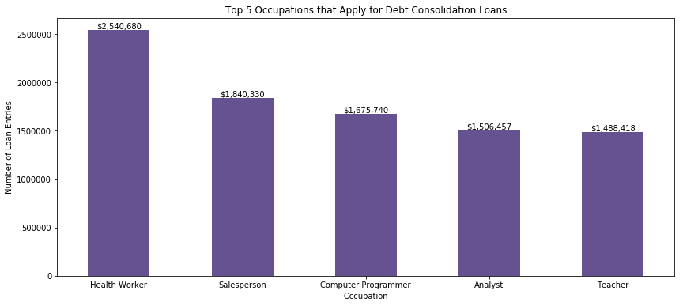

```python
total_debt =(prosper_new
                     .loc[prosper_new.ListingCategory == 1] #which is the dummy for Debt Consolidation
                     #filter off "Other", "Professional", and "Executive"
                     .loc[~(prosper_new.Occupation .isin(['Other', 'Professional', 'Executive']))]
                     .loc[~(prosper_new.LoanStatus == 'Not Completed')] #filter off defaulted loans
                     #group by Occupation and select the first
                     .pipe(lambda df: df.groupby('Occupation')['LoanReturn'].sum().sort_values(ascending=False))[:5]
          )

ax = total_debt.plot(kind='bar',color =['#665191'],title='Top 5 Occupations that Apply for Debt Consolidation Loans',rot=0,figsize=(14,6))
plt.xlabel('Occupation')
plt.ylabel('Number of Loan Entries')

# # Move the legend outside of the chart to make the chart more smoother
# ax.legend(loc='center left', bbox_to_anchor=(1, 0.5))

# Add values on top of the bars
for p in ax.patches:
    ax.annotate('${:,.0f}'.format(p.get_height()),
                (p.get_x() + p.get_width() / 2., p.get_height()),
                ha='center', va='center', xytext=(0, 5),
                textcoords='offset points')
```

#### Observations: It appears that healthworkers, salespeople and computer programmer maintains the top positions

#### Question: Recall that Health Workers were the most people who apply for loans. What loans do they apply for and what's the completion rate in each category?

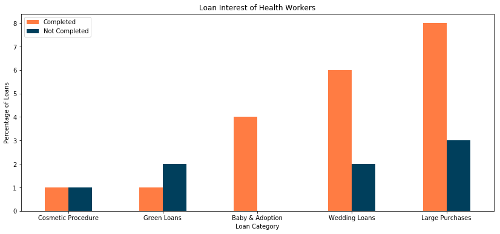

```python
health= (prosper_new
             .loc[prosper_new.Occupation =='Health Worker']
             #filter of current loans
             .loc[~(prosper_new.LoanStatus =='Current')]
             .assign(ListingCategory =lambda df:df.ListingCategory.map({0 : 'Not Available', 1 : 'Debt Consolidation', 2 : 'Home Improvement', 3 : 'Business', 4 : 'Personal Loan', 5 : 'Student Use', 6 : 'Auto', 7: 'Other', 8 : 'Baby & Adoption', 9 : 'Boat', 10 : 'Cosmetic Procedure', 11 : 'Engagement Ring', 12 : 'Green Loans', 13 : 'Household Expenses', 14 : 'Large Purchases', 15 : 'Medical/Dental', 16 : 'Motorcycle', 17 : 'RV', 18 : 'Taxes', 19 : 'Vacation', 20 : 'Wedding Loans'}))
             .pipe(lambda df: df.groupby(['ListingCategory','LoanStatus'])['ListingKey'].count().unstack().sort_values(by='Completed'))[:5]
        )
health.plot(kind='bar',color =['#ff7c43','#003f5c'],title='Loan Interest of Health Workers',rot=0,figsize=(14,6))
plt.xlabel('Loan Category')
plt.ylabel('Percentage of Loans');
plt.legend(loc='best');
```

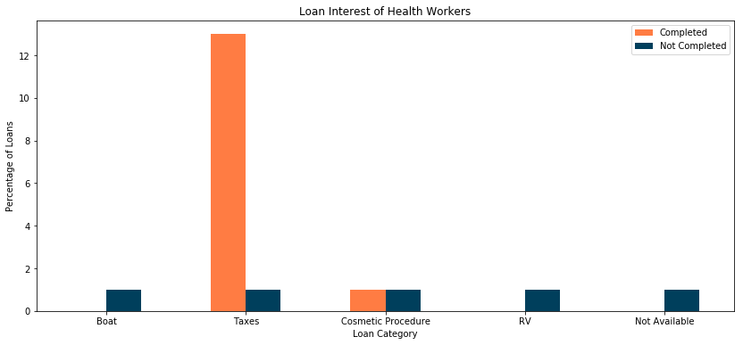

```python
health= (prosper_new
             .loc[prosper_new.Occupation =='Health Worker']
             #filter of current loans
             .loc[~(prosper_new.LoanStatus =='Current')]
             .assign(ListingCategory =lambda df:df.ListingCategory.map({0 : 'Not Available', 1 : 'Debt Consolidation', 2 : 'Home Improvement', 3 : 'Business', 4 : 'Personal Loan', 5 : 'Student Use', 6 : 'Auto', 7: 'Other', 8 : 'Baby & Adoption', 9 : 'Boat', 10 : 'Cosmetic Procedure', 11 : 'Engagement Ring', 12 : 'Green Loans', 13 : 'Household Expenses', 14 : 'Large Purchases', 15 : 'Medical/Dental', 16 : 'Motorcycle', 17 : 'RV', 18 : 'Taxes', 19 : 'Vacation', 20 : 'Wedding Loans'}))
             .pipe(lambda df: df.groupby(['ListingCategory','LoanStatus'])['ListingKey'].count().unstack().sort_values(by='Not Completed'))[:5]
        )
health.plot(kind='bar',color =['#ff7c43','#003f5c'],title='Loan Interest of Health Workers',rot=0,figsize=(14,6))
plt.xlabel('Loan Category')
plt.ylabel('Percentage of Loans');
plt.legend(loc='best');
```

#### Question: Which occupation coupled with credit ratings are likely to make the most money?

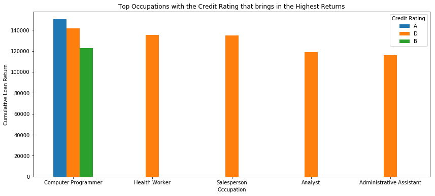

```python
(prosper_new
      #select completed loans and loans in their final payment
     .loc[(prosper_new.LoanStatus == 'Completed')]
     #filter off "Other", "Professional", and "Executive"
    .loc[~(prosper_new.Occupation .isin(['Other', 'Professional', 'Executive']))]
     .groupby(['Occupation','ProsperRating'])['LoanReturn'].sum().sort_values(ascending=False)[:7]
     .unstack()
     .plot(kind='bar', figsize=(14,6), rot=0, title='Top Occupations with the Credit Rating that brings in the Highest Returns')
)
plt.xlabel('Occupation')
plt.ylabel('Cumulative Loan Return')
plt.legend(title='Credit Rating');
```

#### Observations: Computer Programmers make the most money for the loan firm

#### Question: Are you sure those guys above do not default on their loans? Who are the people that were supposed to make the firm money but yet to complete their payment?

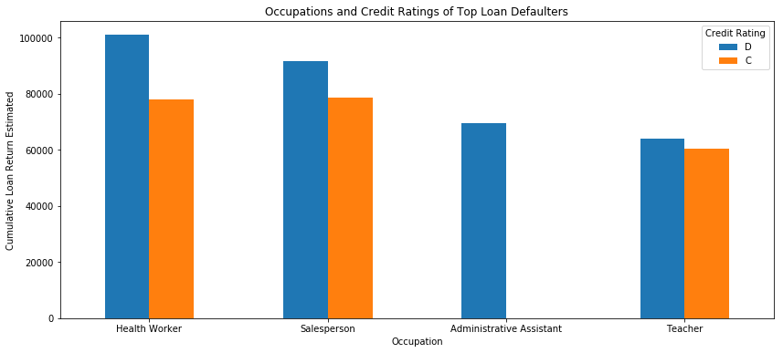

```python
(prosper_new
      #select completed loans and loans in their final payment
     .loc[(prosper_new.LoanStatus == 'Not Completed')]
     #filter off "Other", "Professional", and "Executive"
    .loc[~(prosper_new.Occupation .isin(['Other', 'Professional', 'Executive']))]
     .groupby(['Occupation','ProsperRating'])['LoanReturn'].sum().sort_values(ascending=False)[:7]
     .unstack()
     .plot(kind='bar', figsize=(14,6), rot=0, title='Occupations and Credit Ratings of Top Loan Defaulters')
)
plt.xlabel('Occupation')
plt.ylabel('Cumulative Loan Return Estimated')
plt.legend(title='Credit Rating');
```

#### Observations: Yep, Health Workers and Salesperson might make you money or refuse to pay you back. The money is on the computer programmer

#### Is there a correlation between income range and being a homeowner

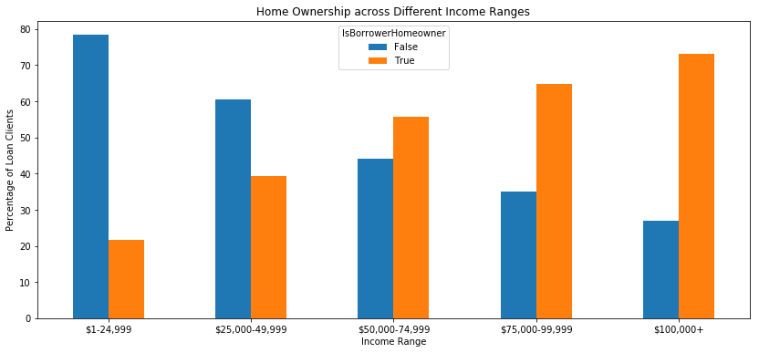

```python
(prosper_new
     .groupby(['IncomeRange','IsBorrowerHomeowner'])['ListingKey'].count().groupby(level=0).transform(lambda x: x/x.sum()*100).sort_values(ascending=False)[:10]
     .unstack()
     .plot(kind='bar', figsize=(14,6), rot=0, title='Home Ownership across Different Income Ranges')
)

plt.xlabel('Income Range')
plt.ylabel('Percentage of Loan Clients');
```

#### Observations: As expected, the more you earn, the higher the chances that you might be a homeowner. This might be a useful or useless information :)

#### Question: For the debt consolidation loans given most to people with C Credit Rating. Do they pay back or they default?

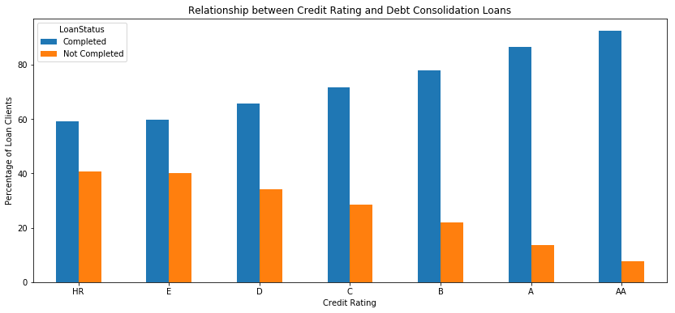

```python
top_debt =(prosper_new
             .loc[prosper_new.ListingCategory == 1] #which is the dummy for Debt Consolidation
               #filter of current loans
             .loc[~(prosper_new.LoanStatus =='Current')]
             #group by Occupation and select the first
             .pipe(lambda df: df.groupby(['ProsperRating','LoanStatus'])['ListingKey'].count().groupby(level=0).transform(lambda x: x/x.sum()*100).unstack())
          )

# plotter(top_debt, '#d45087' )
top_debt.plot(kind='bar', title='Relationship between Credit Rating and Debt Consolidation Loans', rot=0,figsize=(14,6))
plt.xlabel('Credit Rating')
plt.ylabel('Percentage of Loan Clients');
```

#### Observations: Well, they have more than 70% repayment rate so that should count for something. Generally, people with higher credit ratings repay loan on time. Guess that's why they have the high credit rating in the first place

### Talk about some of the relationships you observed in this part of the investigation. Were there features that strengthened each other in terms of looking at your feature(s) of interest?

> Credit Score, Occupation, Loan Term, and Loan Category determines how much a client can access